# Datenanalyse - Laborprotokoll

Gruppe 1_b

Author

Jan Aspan, Felix Bachmann, Niklas Grundner, Julian Resch, Sebastian Sarria Suarez

Published

26. April 2025

## 1 Abstract

From DNA samples to taxonomic classification.

Known sample origin:

1. oral swab sample
2. room monitoring sample
3. single cultured microorganism
4. ZymoBIOMICS HMW DNA standard from ZymoResearch (Cat.# D6322)

## 2 Background

### Oxford Nanopore Sequencing

Nanopore sequencing (often referred to as Oxford Nanopore Sequencing or ONT sequencing) is a single-molecule technology in which individual strands of DNA or RNA are pulled through a biological nanopore channel in an electrically insulating membrane. An applied voltage (~180 mV) generates a constant ionic base current; as soon as a nucleic acid segment passes through the narrowest part of the pore, the combination of about five consecutive bases located there changes the electrical resistance. These characteristic current fluctuations (‘squiggles’) are digitised at a kHz sampling rate and then translated into nucleotide sequences using deep neuronal-based base callers (e.g. guppy flip-flop RNN or Dorado). An upstream motor protein - a modified helicase/polymerase - regulates the translocation speed (70 - 450 bp s-¹ with current R9.4 chemistry) and removes double strands. The method works purely electrically, does not require fluorescent dyes or PCR steps and therefore enables extremely long reads (record-verified > 2 Mbp), real-time data flow and the immediate detection of epigenetic base modifications and native RNA. Today’s commonly used por generations (R9.4, R10.3) achieve raw read error rates of 5 - 10 % and consensus accuracies > 99.9 % after polishing.[1][2]

#### Metrics for performance evaluation

Current benchmarks essentially use four key figures, partly already defined in the Wick paper, now formalised:[3][4]

1. read accuracy: median sequence identity of individual reads against a reference, usually as Phred-Q (-10 log₁₀ error) or “modal accuracy”.
2. consensus accuracy: Identity of a consensus generated from many reads; important for assemblies/variant calling.
3. Failure rate: Percentage of raw streams that cannot be decoded by the base caller.
4. throughput / speed: Bases per second on defined hardware (GPU/CPU). In addition, homopolymer errors, modified-base detection F1 score (for Remora/Dorado) and computational cost (watt-hours per Gb) are shown in more recent work.

### Metagenom

A metagenome is the entirety of all genetic sequences obtained directly from a complex sample (such as soil, seawater or the human gut). Instead of first isolating individual microorganisms in pure culture, the entire DNA or RNA mixture is extracted and sequenced; this provides an overview of all members of the community and their genetic potential in a single step.[5]

Metagenomes are being analysed because they answer questions that can hardly or not at all be solved with classical culture methods:

• Uncovering hidden biodiversity: It is estimated that more than 90 % of the microbial world cannot (or can only with difficulty) be cultivated; metagenomic approaches open up this ‘dark matter’ of the microbiome.[6]

• Understanding ecological functions: By analysing the enzymes encoded in the metagenome, it is possible to reconstruct which metabolic pathways take place in a habitat and how microbes influence global cycles (carbon, nitrogen, etc.).[7]

• Medical diagnostics and microbiome research: In the human body, metagenomics helps to detect pathogens or resistance genes without prior knowledge and to uncover connections between dysbioses and diseases.[8]

• Biotechnological treasure hunt: Novel enzymes and bioactive substances originate from environmental metagenomes, which can be used in industry, environmental technology or pharmaceuticals.[9]

• Environmental and process monitoring: Sequence-based monitoring of wastewater, fermenters or drinking water systems enables the early detection of contamination or process disruptions.[10]

• Evolutionary insights: Time series or sediment samples show how microbial communities genetically adapt to climate and environmental changes.[11][12]

### Taxonomic classification

Taxonomic classification is the computer-aided step in which sequence reads or longer contigs of a biological sample are assigned to a hierarchical category of life (i.e. species, genus, family, etc.). In practice, classification follows directly after sequencing and answers the question: ‘Which organisms (or genes) are in my data set?’[13]

Read-based classification assigns each raw read directly to a reference database. This is fast and can be applied even with low coverage.[13]

Assembly-based classification first assembles reads into contigs or whole genomes; this increases accuracy and enables functional annotation, but requires higher computing power as a result.[13]

Typical tools such as Centrifuge, Kraken 2 (k-mer-based) or Kaiju (protein-level) are available on many bioinformatics servers. The choice of database and parameters influences the sensitivity and precision of the classification.[13]

Taxonomic classification is important for the following points:

• Recording biodiversity: Only taxonomic classification turns an anonymous sequence collection into an ecological ‘species list’ and shows which taxa are present or absent in a habitat.[14]

• Clinical diagnostics & epidemiology: Rapid detection of pathogens or resistance genes in patient samples supports therapeutic decisions and outbreak monitoring.[15]

• Food and environmental monitoring: Detection of undesirable microorganisms in production chains or waters is often only possible via metagenomic classification.[16]

• Functional interpretation: Many bioinformatics pipelines combine taxa information with gene annotation steps; this makes it possible to deduce which groups of organisms encode certain metabolic pathways or toxins.[17]

• Bias control & quality check: By comparing expected and observed taxa, contamination or gaps in reference databases can be recognised; false positives/negatives can be quantified.[13]

## 3 Methods

### Sample preparation and sequencing

Sample preparation was done according to *Rapid sequencing DNA V14 - barcoding (SQK-RBK114.24 or SQK-RBK114.96)*. Any additional required steps are explained in detail in *GRUPPE_1_B_20250212_Labprotocol*. The output of the oxford nanopore basecaller is in the further steps described as “sample”.

### Data processing pipeline

To get one hand a meaningful result and on the other one a better insight into what effect quality control and filtering has, two slightly different workflows were defined for data analysis.  
For the first one only minimal quality control and no filtering was used while for the second one further quality control and filtering was used.

#### Workflow 1 - minimal QC and no filtering

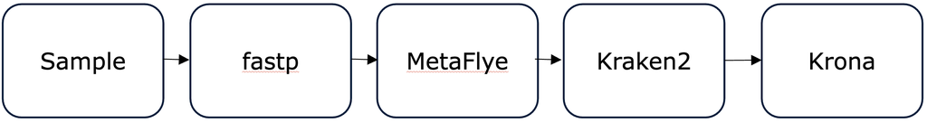

Workflow 1 with minimal QC and no filtering.

#### Workflow 2 - extended QC and filtering

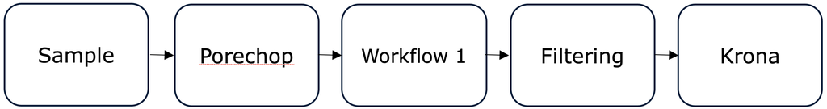

Workflow 2 with extended QC and filtering

## 4 Results

### Sample 1

Sample 1 taxonomy classification with Kraken 2 was performed with different approaches to the sequence assembly. For each approach polishing and filtering steps with Porechop (adapter trimming) Fastp (discard nucleotides <10 phred score) and a manual awk filtering step were performed. After the preparation steps assembly was performed with Metaflye, Raven and a classification with no assembly at all. Since Raven assemblies are the most representative assemblies for our samples the results of Raven and the classification without an assembly are shown here (the Metaflye assembly data shows very similar results, but are not relevant for further analysis)

Quality control with `FastQC` revealed 1460282 sequences (GC 42%), with low base quality in short reads. After adapter and quality filtering using `Porechop` and `Fastp`, 1384890 high-quality reads (GC 42%) remained.

Krona output of workflow with Raven assembly of sample 1:

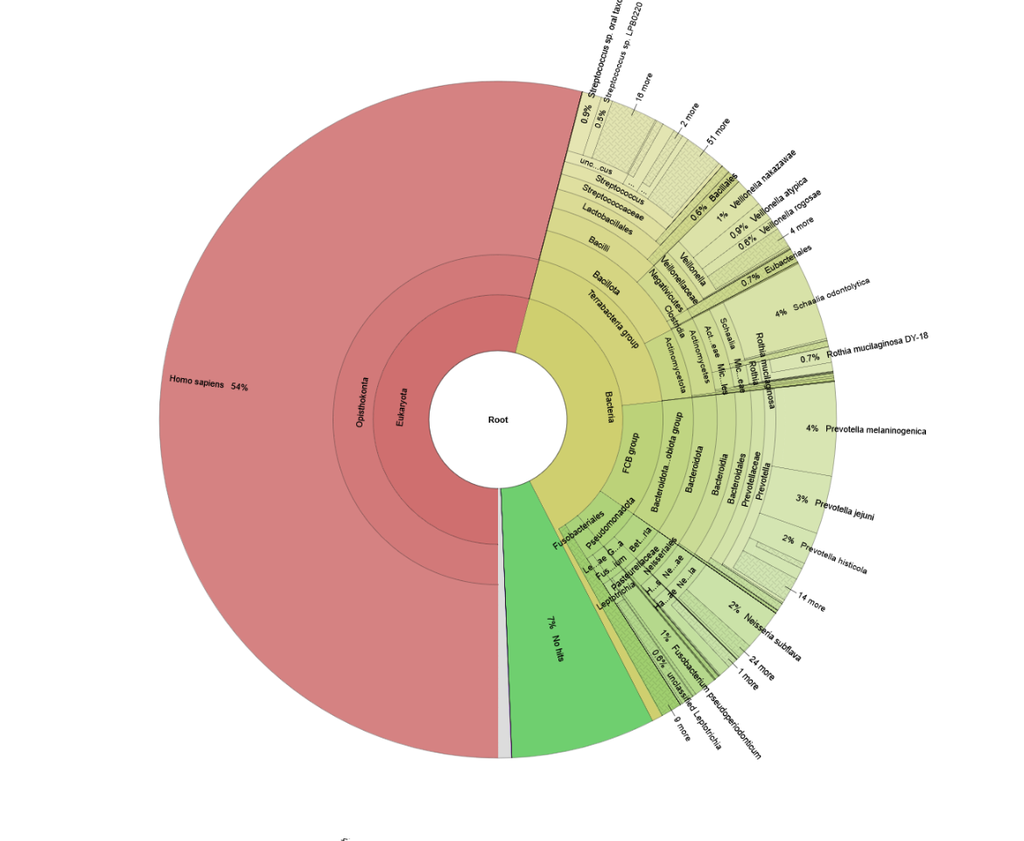

Figure 1: Krona chart showing taxonomic composition of sample 1 assembled via Raven

Krona output of workflow with no assembly of sample 1:

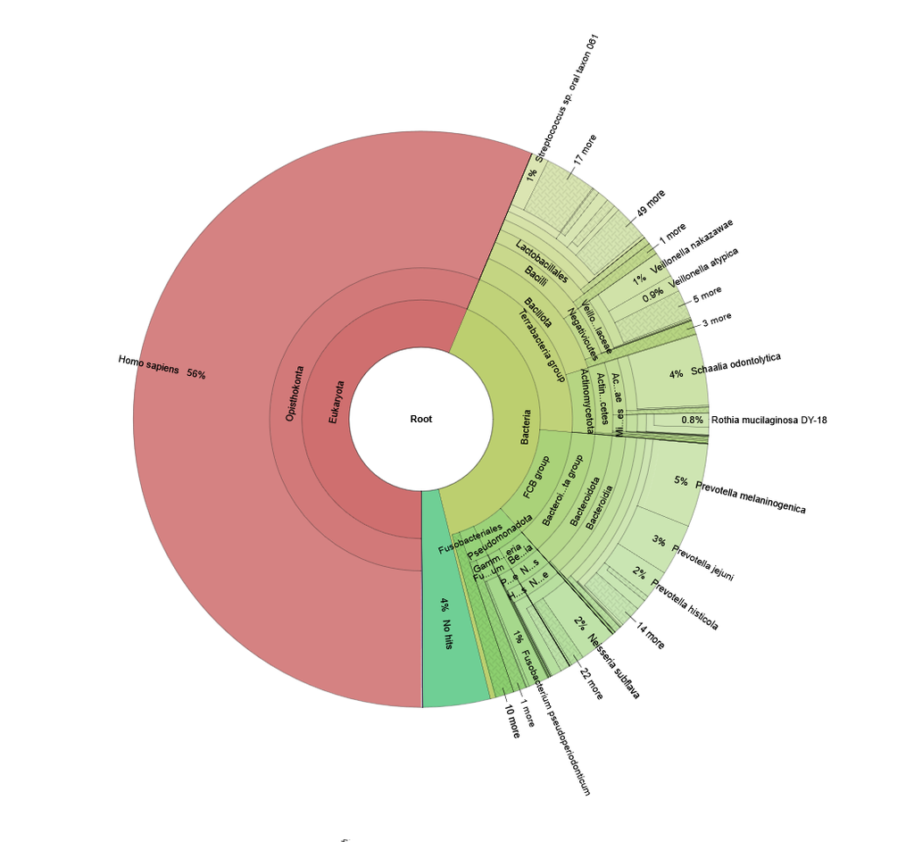

Figure 2: Krona chart showing taxonomic composition of sample 1 alternative workflow (no assembly)

Comparison of Top 8 relativ abundand organisms from Krona classificiation output:

| Taxon (Top 8) | Relative abundance [%] | Relative abundance alt [%] |
| --- | --- | --- |
| Homo sapiens | 54 | 56 |
| Prevotella melaninogenica | 4 | 5 |
| Schaalia odontolytica | 4 | 4 |
| Prevotella jejuni | 3 | 3 |
| Prevotella histicola | 2 | 2 |
| Neisseria subflava | 2 | 2 |
| Fusobacterium pseudoperiodonticum | 1 | 1 |
| Veillonella nakazawae | 1 | 1 |

### Sample 2

Sample 2 analysis was performed with the same polishing and filtering steps as sample 1 (Porechop (adapter trimming) Fastp (discard nucleotides <10 phred score) and a manual awk filtering). Here too an assembly with Metaflye and Raven was performed. The results showed very similar numbers and Metaflye outputs are not shown in this report (as Raven stays the most representative assembler for our samples).

Quality control with `FastQC` revealed 281153 sequences (GC 41%), with low base quality in short reads. After adapter and quality filtering using `Porechop` and `Fastp`, 254349 high-quality reads (GC 41%) remained.

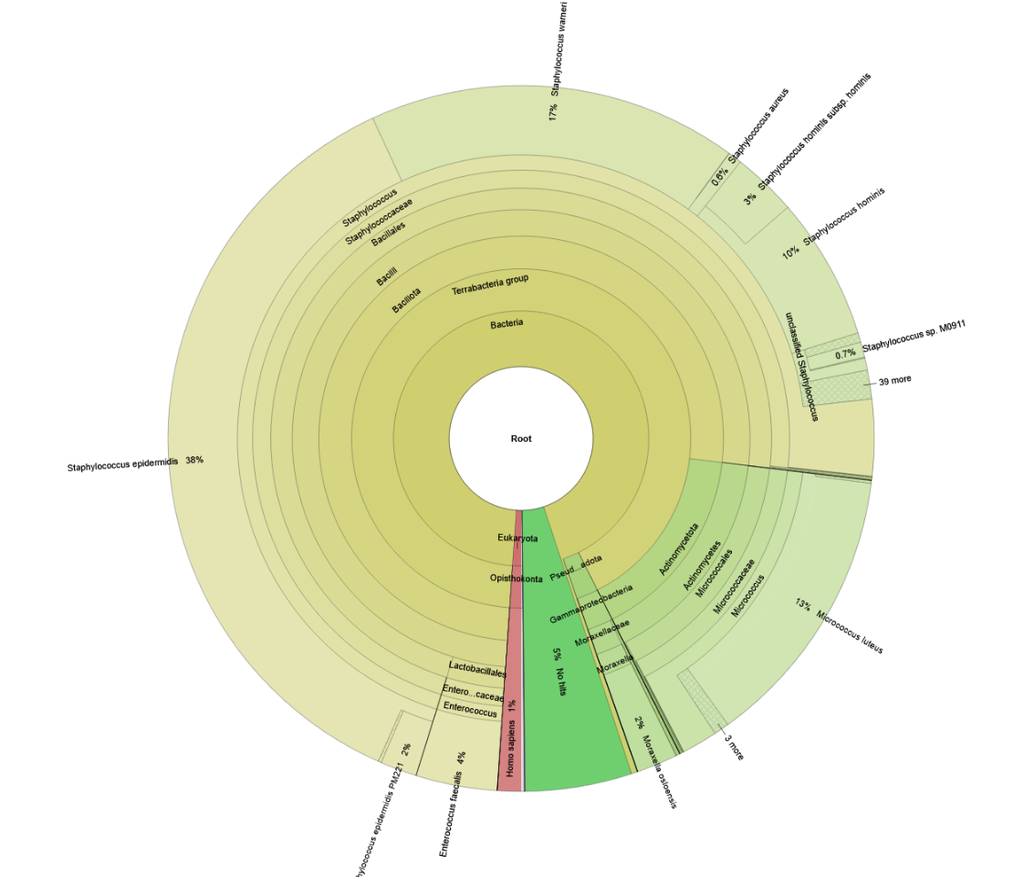

Figure 3: Krona chart showing taxonomic composition of sample 2 assembled via Raven

| Taxon (Top 8) | Relative abundance [%] |
| --- | --- |
| Staphylococcus epidermidis | 38 |
| Staphylococcus warneri | 17 |
| Micrococcus luteus | 13 |
| Staphylococcus hominis | 10 |
| Enterococcus faecalis | 4 |
| Staphylococcus hominis subsp. hominis | 3 |
| Moraxella osloensis | 2 |

### Sample 3

Sample 3 was processed using `Metaflye`, `Raven`, and `Canu` for assembly. Quality control with `FastQC` revealed 672,323 sequences (GC 69%), with low base quality in short reads. After adapter and quality filtering using `Porechop` and `Fastp`, 481,272 high-quality reads (GC 72.8%) remained, with a mean length of 1,833 bp and a duplication rate below 7.4%.

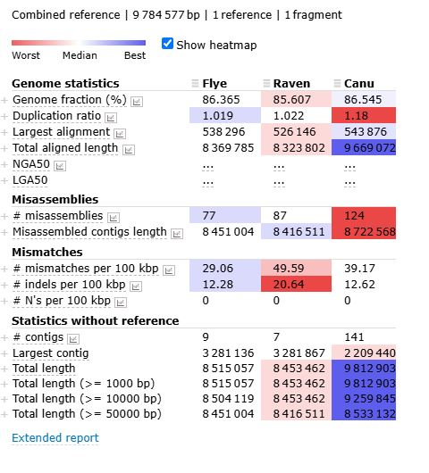

Figure 4: Assembly statistics comparison generated by MetaQUAST.

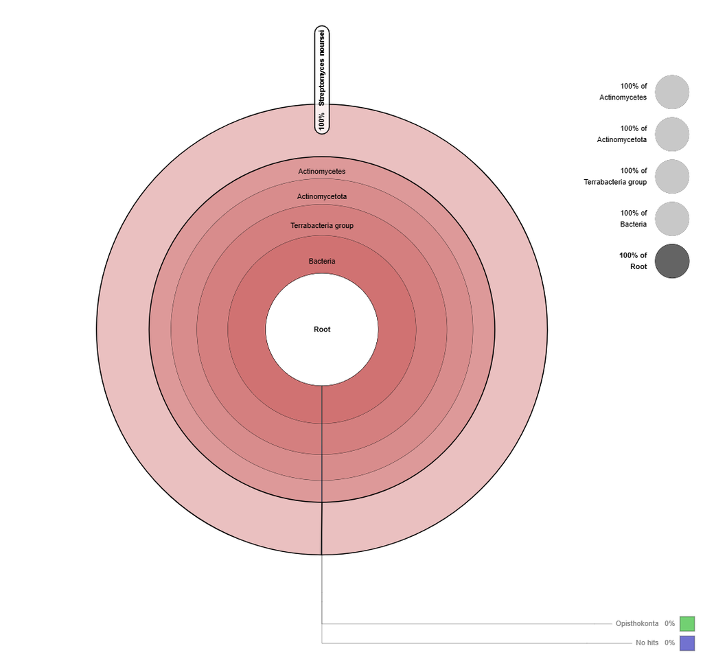

Figure 5: Krona chart showing taxonomic composition.

### Sample 4

Sample 4 was successfully assembled using `Raven`, while assemblies with `Metaflye` and `Canu` did not yield usable results. Quality control after adapter and quality trimming indicated that the dataset contained a sufficient number of high-quality reads for assembly.

The most abundant taxa included `Bacillus subtilis` (13%), `Enterococcus faecalis` (12%), and `Salmonella enterica` (10%). The following table summarizes the most represented species detected.

Taxons and their relative abundance in Sample 4

| Taxon | Relative abundance [%] |
| --- | --- |
| Bacillus subtilis | 13 |
| Enterococcus faecalis | 12 |
| Salmonella enterica | 10 |
| Escherichia coli | 9 |
| Pseudomonas aeruginosa | 9 |
| Listeria monocytogenes | 8 |
| Saccharomyces cerevisiae | 2 |

## 5 Discussion

## 6 References

[1] Wang, Y., Zhao, Y., Bollas, A. et al. Nanopore sequencing technology, bioinformatics and applications. Nat Biotechnol 39, 1348–1365 (2021)

[2] Waldherr M. Data Analysis Lab – Sequencing (Vorlesungsfolien, Master Bioinformatik, SS 2025)

[3] Pagès-Gallego, M., de Ridder, J. Comprehensive benchmark and architectural analysis of deep learning models for nanopore sequencing basecalling. Genome Biol 24, 71 (2023)

[5] Thomas, T., Gilbert, J. & Meyer, F. Metagenomics - a guide from sampling to data analysis. Microb Informatics Exp 2, 3 (2012)

[6] Vigdis Torsvik, Lise Øvreås, Microbial diversity and function in soil: from genes to ecosystems, Current Opinion in Microbiology, Volume 5, Issue 3, Pages 240-245, ISSN 1369-5274 (2002)

[9] Zhang L, Chen F, Zeng Z, Xu M, Sun F, Yang L, Bi X, Lin Y, Gao Y, Hao H, Yi W, Li M, Xie Y. Advances in Metagenomics and Its Application in Environmental Microorganisms. Front Microbiol. (2021)

[10] Prayogo FA, Budiharjo A, Kusumaningrum HP, Wijanarka W, Suprihadi A, Nurhayati N. Metagenomic applications in exploration and development of novel enzymes from nature: a review. J Genet Eng Biotechnol. (2020)

[11] Krinos, A., Bowers, R., Rohwer, R. et al. Time-series metagenomics reveals changing protistan ecology of a temperate dimictic lake. Microbiome 12, 133. (2024)

[12] Garner RE, Gregory-Eaves I, Walsh DA. Sediment Metagenomes as Time Capsules of Lake Microbiomes. mSphere. (2020)

[13] Waldherr M. Data Analysis Lab – Classification (Vorlesungsfolien, Master Bioinformatik, SS 2025)

[14] Kumar Awasthi M, Ravindran B, Sarsaiya S, Chen H, Wainaina S, Singh E, Liu T, Kumar S, Pandey A, Singh L, Zhang Z. Metagenomics for taxonomy profiling: tools and approaches. Bioengineered. (2020)

[15] Jia, X., Hu, L., Wu, M. et al. A streamlined clinical metagenomic sequencing protocol for rapid pathogen identification. Sci Rep 11, 4405 (2021)

[16] Maguire, Meghan & Kase, Julie & Roberson, Dwayne & Muruvanda, Tim & Brown, Eric & Allard, Marc & Musser, Steven & González-Escalona, Narjol. Precision long-read metagenomics sequencing for food safety by detection and assembly of Shiga toxin-producing Escherichia coli in irrigation water (2021)

[17] Maranga M, Szczerbiak P, Bezshapkin V, Gligorijevic V, Chandler C, Bonneau R, Xavier RJ, Vatanen T, Kosciolek T. Comprehensive Functional Annotation of Metagenomes and Microbial Genomes Using a Deep Learning-Based Method. mSystems. (2023)

## 7 Links

[4] Oxford Nanopore Technologies. https://nanoporetech.com/support/software/data-analysis/where-can-i-find-out-more-about-quality-scores [Accessed 24 April 2025]

[7] National Research Council (US) Committee on Metagenomics: Challenges and Functional Applications. The New Science of Metagenomics: Revealing the Secrets of Our Microbial Planet. Washington (DC): National Academies Press (US); 2007. 1, Why Metagenomics? Available from: https://www.ncbi.nlm.nih.gov/books/NBK54011/ [Accessed 24 April 2025]

[8] CD Genomics the Genomics Services Company: Applications of Metagenomics in Biotechnology and Health Care. https://www.cd-genomics.com/applications-of-metagenomics-in-biotechnology-and-health-care.html? [Accessed 24 April 2025]